# 데이터마이닝 방법 및 실습 프로젝트 제안서

## 런던 지역 집값 예측 및 인구통계 기반 분석

오종현

# 연구 배경

최근 부동산 시장은 단순한 수요와 공급의 문제를 넘어, 지역의 인구 구성, 사회문화적 특성, 교통 인프라 등 다양한 요인들과 밀접한 연관을 보이고 있다. 특히 런던과 같은 대도시는 인종, 언어, 종교 등 다양한 배경을 지닌 사람들이 공존하는 복합적인 공간으로, 이러한 지역적 특성과 주택 가격 간의 관계를 파악하는 것은 도시 구조와 시장 변동성을 이해하는 데 중요한 기반이 된다.

# 연구 목적

본 프로젝트의 목적은 런던 내 주택 가격 데이터를 기반으로, 지역별 인구통계 데이터를 결합하여 집값에 영향을 미치는 주요 요인을 파악하고 예측 모델을 구축하는 것이다. 인종, 언어, 종교 등의 인구통계적 특성이 주택 가격에 어떤 영향을 미치는지, 단순한 위치 정보 외에 지역의 사회·문화적 특성을 반영한 모델이 더 나은 예측력을 가질 수 있는지를 살펴보고자 한다. 또한, 고가 및 저가 지역의 공통된 특성을 시각화하여 해석하는 데에도 목적이 있다.

더불어 2022년 5월에 개통된 런던의 새로운 고속 지하철 노선인 엘리자베스 라인의 영향을 분석할 예정이다. 엘리자베스 라인은 동서 방향으로 광범위하게 확장되어 도심과 외곽을 빠르게 연결하며, 개통 이후 교통 접근성 개선과 인근 부동산 가치 상승에 영향을 미쳤다는 평가를 받고 있다. 따라서 주택의 위도와 경도 정보를 활용해 가장 가까운 엘리자베스 라인 역까지의 거리를 계산하고, 해당 거리와 주택 가격 간의 관계를 통계적으로 분석하여 교통 인프라의 영향을 정량적으로 평가하고자 한다.

# 데이터 설명

사용 데이터: https://www.kaggle.com/datasets/jakewright/house-price-data/data https://data.london.gov.uk/dataset/2021-census-wards-ethnicity-language-identity-religion

# EDA

```python
import pandas as pd
LDN = pd.read_csv('london_houses.csv')
LDN.columns.tolist()
```

```
['fullAddress',
 'postcode',
 'country',
 'outcode',
 'latitude',
 'longitude',
 'bathrooms',
 'bedrooms',
 'floorAreaSqM',
 'livingRooms',
 'tenure',
 'propertyType',
 'currentEnergyRating',
 'rentEstimate_lowerPrice',
 'rentEstimate_currentPrice',
 'rentEstimate_upperPrice',
 'saleEstimate_lowerPrice',
 'saleEstimate_currentPrice',
 'saleEstimate_upperPrice',
 'saleEstimate_confidenceLevel',
 'saleEstimate_ingestedAt',
 'saleEstimate_valueChange.numericChange',
 'saleEstimate_valueChange.percentageChange',
 'saleEstimate_valueChange.saleDate',
 'history_date',
 'history_price',
 'history_percentageChange',
 'history_numericChange',
 'pcd',
 'lad23cd',
 'lad23nm',
 'pct_christian',
 'pct_buddhist',
 'pct_hindu',
 'pct_jewish',
 'pct_muslim',
 'pct_sikh',
 'pct_other_religion',
 'pct_none',
 'pct_not_stated',
 'local authority code',
 'pct_white_brit',
 'pct_white_irish',
 'pct_gypsy',
 'pct_white_other',
 'pct_mixed_white_asian',
 'pct_mixed_white_black_african',
 'pct_mixed_white_black_caribbean',
 'pct_mixed_other',
 'pct_bangladeshi',
 'pct_chinese',
 'pct_indian',
 'pct_pakistani',
 'pct_asian_other',
 'pct_african',
 'pct_caribbean',
 'pct_black_other',
 'pct_arab',
 'pct_other_ethnicity']
```

```python
print(LDN.shape)
print(LDN.dtypes)
```

[output not shown]

```python
LDN.isnull().sum()
```

```
fullAddress                                       0
postcode                                          0
country                                           0
outcode                                           0
latitude                                          0
longitude                                         0
bathrooms                                     54243
bedrooms                                      26035
floorAreaSqM                                  16787
livingRooms                                   40698
tenure                                         7253
propertyType                                    810
currentEnergyRating                           59701
rentEstimate_lowerPrice                        1193
rentEstimate_currentPrice                      1193
rentEstimate_upperPrice                        1193
saleEstimate_lowerPrice                         425
saleEstimate_currentPrice                       425
saleEstimate_upperPrice                         425
saleEstimate_confidenceLevel                    425
saleEstimate_ingestedAt                         425
saleEstimate_valueChange.numericChange          425
saleEstimate_valueChange.percentageChange       425
saleEstimate_valueChange.saleDate               425
history_date                                      0
history_price                                     0
history_percentageChange                     131378
history_numericChange                        131378
pcd                                               0
lad23cd                                           0
lad23nm                                           0
pct_christian                                     0
pct_buddhist                                      0
pct_hindu                                         0
pct_jewish                                        0
pct_muslim                                        0
pct_sikh                                          0
pct_other_religion                                0
pct_none                                          0
pct_not_stated                                    0
local authority code                              0
pct_white_brit                                    0
pct_white_irish                                   0
pct_gypsy                                         0
pct_white_other                                   0
pct_mixed_white_asian                             0
pct_mixed_white_black_african                     0
pct_mixed_white_black_caribbean                   0
pct_mixed_other                                   0
pct_bangladeshi                                   0
pct_chinese                                       0
pct_indian                                        0
pct_pakistani                                     0
pct_asian_other                                   0
pct_african                                       0
pct_caribbean                                     0
pct_black_other                                   0
pct_arab                                          0
pct_other_ethnicity                               0
dtype: int64
```

```python
LDN = LDN[LDN['saleEstimate_currentPrice'].notna()].copy()
LDN.isnull().sum()
```

```
fullAddress                                       0
postcode                                          0
country                                           0
outcode                                           0
latitude                                          0
longitude                                         0
bathrooms                                     54151
bedrooms                                      25959
floorAreaSqM                                  16714
livingRooms                                   40606
tenure                                         7244
propertyType                                    804
currentEnergyRating                           59587
rentEstimate_lowerPrice                         768
rentEstimate_currentPrice                       768
rentEstimate_upperPrice                         768
saleEstimate_lowerPrice                           0
saleEstimate_currentPrice                         0
saleEstimate_upperPrice                           0
saleEstimate_confidenceLevel                      0
saleEstimate_ingestedAt                           0
saleEstimate_valueChange.numericChange            0
saleEstimate_valueChange.percentageChange         0
saleEstimate_valueChange.saleDate                 0
history_date                                      0
history_price                                     0
history_percentageChange                     131197
history_numericChange                        131197
pcd                                               0
lad23cd                                           0
lad23nm                                           0
pct_christian                                     0
pct_buddhist                                      0
pct_hindu                                         0
pct_jewish                                        0
pct_muslim                                        0
pct_sikh                                          0
pct_other_religion                                0
pct_none                                          0
pct_not_stated                                    0
local authority code                              0
pct_white_brit                                    0
pct_white_irish                                   0
pct_gypsy                                         0
pct_white_other                                   0
pct_mixed_white_asian                             0
pct_mixed_white_black_african                     0
pct_mixed_white_black_caribbean                   0
pct_mixed_other                                   0
pct_bangladeshi                                   0
pct_chinese                                       0
pct_indian                                        0
pct_pakistani                                     0
pct_asian_other                                   0
pct_african                                       0
pct_caribbean                                     0
pct_black_other                                   0
pct_arab                                          0
pct_other_ethnicity                               0
dtype: int64
```

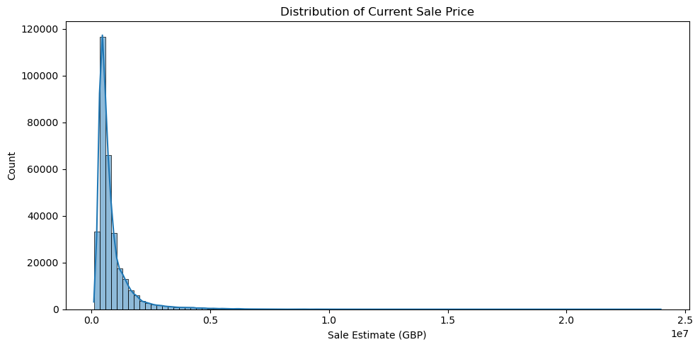

```python
import matplotlib.pyplot as plt
import seaborn as sns

plt.figure(figsize=(10, 5))
sns.histplot(LDN['saleEstimate_currentPrice'], bins=100, kde=True)

plt.title("Distribution of Current Sale Price")
plt.xlabel("Sale Estimate (GBP)")
plt.ylabel("Count")
plt.tight_layout()
plt.show()
```

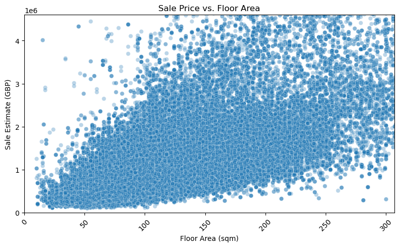

```python
plt.figure(figsize=(8, 5))
sns.scatterplot(data=LDN, x='floorAreaSqM', y='saleEstimate_currentPrice', alpha=0.3)
plt.xlim(0, LDN['floorAreaSqM'].quantile(0.99))
plt.ylim(0, LDN['saleEstimate_currentPrice'].quantile(0.99))
plt.xticks(rotation=45)
plt.title("Sale Price vs. Floor Area")
plt.xlabel("Floor Area (sqm)")
plt.ylabel("Sale Estimate (GBP)")
plt.tight_layout()
plt.show()
```

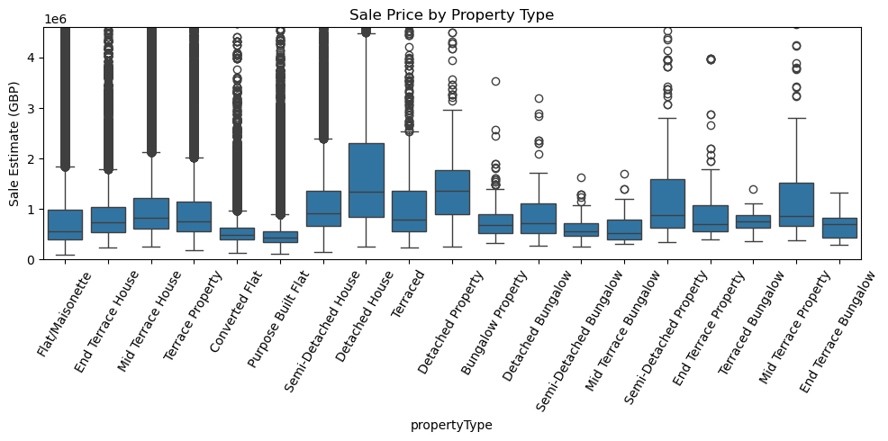

```python
plt.figure(figsize=(10, 5))
sns.boxplot(data=LDN, x='propertyType', y='saleEstimate_currentPrice')
plt.ylim(0, LDN['saleEstimate_currentPrice'].quantile(0.99))
plt.xticks(rotation=60)
plt.title("Sale Price by Property Type")
plt.ylabel("Sale Estimate (GBP)")
plt.tight_layout()
plt.show()
```

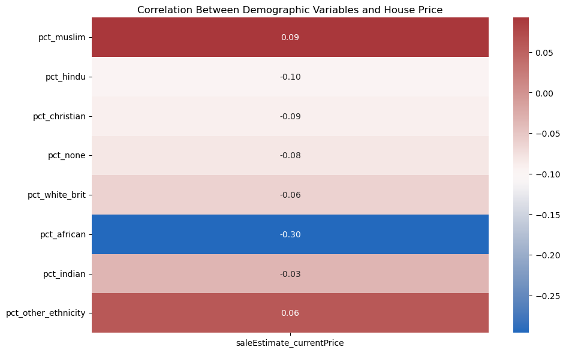

```python
demo_vars = [
    'pct_muslim', 'pct_hindu', 'pct_christian', 'pct_none',
    'pct_white_brit', 'pct_african', 'pct_indian', 'pct_other_ethnicity'
]
corr_df = LDN[demo_vars + ['saleEstimate_currentPrice']].corr()

plt.figure(figsize=(10, 6))
sns.heatmap(corr_df[['saleEstimate_currentPrice']].drop('saleEstimate_currentPrice'), annot=True, cmap='vlag', fmt=".2f")
plt.title("Correlation Between Demographic Variables and House Price")
plt.tight_layout()
plt.show()
```

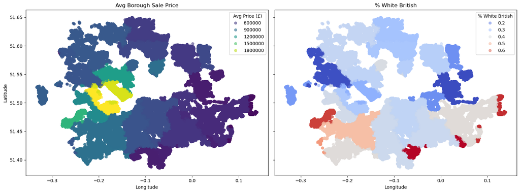

```python
fig, axes = plt.subplots(1, 2, figsize=(16, 6), sharex=True, sharey=True)

sns.scatterplot(
    data=LDN, x='longitude', y='latitude',
    hue='saleEstimate_currentPrice_borough_avg',
    palette='viridis', alpha=0.6, ax=axes[0], edgecolor=None
)
axes[0].set_title("Avg Borough Sale Price")
axes[0].set_xlabel("Longitude")
axes[0].set_ylabel("Latitude")
axes[0].legend().set_title("Avg Price (£)")

# Plot % White British spatially
sns.scatterplot(
    data=LDN, x='longitude', y='latitude',
    hue='pct_white_brit',
    palette='coolwarm', alpha=0.5, ax=axes[1], edgecolor=None
)
axes[1].set_title("% White British")
axes[1].set_xlabel("Longitude")
axes[1].set_ylabel("")
axes[1].legend().set_title("% White British")

plt.tight_layout()
plt.show()
```